# Detecting Medicare Claim Anomalies

# Part 1 - Data Acquisition and Exploration

## Problem Statement

This analysis is based on the challenge possed by [Cloudera Certified Professional: Data Scientist program](http://www.cloudera.com/content/cloudera/en/training/certification/ccp-ds/challenge.html) for their graduating candidates. The probelm statement states the following:

"In the U.S., Medicare reimburses private providers for medical procedures performed for covered individuals. As such, it needs to verify that the type of procedures performed and the cost of those procedures are consistent and reasonable. Finally, it needs to detect possible errors or fraud in claims for reimbursement from providers. You have been hired to analyze a large amount of data from Medicare and try to detect abnormal data -- providers, areas, or patients with unusual procedures and/or claims."

Although this analysis is not aimed as a repsonce to this challenge, the real world problem with curated data sources does tempt one to dig a little deeper. The recent Wall Street Journal article on how [op 1% of medical providers accounted for 14% of billing](http://online.wsj.com/news/articles/SB10001424052702303456104579490043350808268?mg=reno64-wsj&url=http%3A%2F%2Fonline.wsj.com%2Farticle%2FSB10001424052702303456104579490043350808268.html) peaked my interest to use the Cloudera use case as the topic for this post.

This post will be a 3 part series. The firts one will discuss basic data acquisition and prilimanary exploration of data. The second will cover Predective Modeling and the last post will communicating the results using a narrative (story telling) approach.  
In this post, I will attempt to extract and explore statistics about the dataset and present insights on abnormalities in procedur and claim trens. As a biproduct, I hope a data exploration and preparation workflow emerges that I can generalize for use in future analysis.

## Data Acquisition

The following data sources were made available for this challenge. They summerize the procedures performed by a physician and the related charges sent to Medicare for reimbersement.

1. [Medicare Provider Charge Data: Inpatient](http://www.cms.gov/Research-Statistics-Data-and-Systems/Statistics-Trends-and-Reports/Medicare-Provider-Charge-Data/Inpatient.html)
2. [Medicare Provider Charge Data: Outpatient](http://www.cms.gov/Research-Statistics-Data-and-Systems/Statistics-Trends-and-Reports/Medicare-Provider-Charge-Data/Outpatient.html)

### Acquier Data

The grainularity of data for Inpatient and Outpatient is the same. The difference is in the size of the file. The Inpatient file has more records as the the volume of Inpatient procedure is more (which in itself can be an area of exploration). For logistical reasons, I have choosen the Outpatient dataset first. The Outpatient data, (like the Inpatient dataset) is provided in two bundles: [Outpatient Charge Data, CY2011, Comma Separated Values (CSV) version](http://www.cms.gov/Research-Statistics-Data-and-Systems/Statistics-Trends-and-Reports/Medicare-Provider-Charge-Data/Downloads/OPPS_APC_CSV.zip) and [National and State Summaries of Outpatient Charge Data, CY2011, Comma Separated Values (CSV) version](http://www.cms.gov/Research-Statistics-Data-and-Systems/Statistics-Trends-and-Reports/Medicare-Provider-Charge-Data/Downloads/OPPS_NAT_STATE_SUM_CSV.zip).

The compressed zip file was downloaded and extracted locally. It contains the following files:

1. Medicare_Provider_Charge_Outpatient_APC30_CY2011_v2.csv - Size 7MB
2. Medicare_Charge_Outpatient_APC30_Summary_by_APC_CY2011_v2.csv - Size 2KB
3. Medicare_Charge_Outpatient_APC30_Summary_by_APCState_CY2011_v2 - Size 107KB

We will start by initializing libraries for iPython Notebook

Initializing requiered iPython libraries

```python
import numpy as np
import pandas as pd
import pandas.tools.rplot as rplot
import pylab as pl
import matplotlib as mpl
import matplotlib.pyplot as plt

#To be able to embed plots inline in the document
%matplotlib inline
pd.set_option('display.notebook_repr_html', False)
pd.set_option('display.max_columns', 20)
pd.set_option('display.max_rows', 50)
```

Load data from the source.

The 'readCSV' is a good python/pandas api for interacting with csv or txt files. A [robust set of libraries](http://pandas.pydata.org/pandas-docs/stable/io.html) are avaialble that interact with JSON, SQL and HDFS5 amongst others.

[OpenRefine](http://openrefine.org/) is a tool that can be handy for data cleansing, data exploration, and data transformation.

```python
#set data source path
path = '/Users/mayank/Google Drive/DataSets/DetectingMedicareClaimAnomalies/DataSet/Extracted/Medicare_Provider_Charge_Outpatient_APC30_CY2011_v2.csv'

header_row = ['APC', 'HCP_Id', 'HCP_Name', 'HCP_St_Add', 'HCP_Add_City', 'HCP_Add_State', 'HCP_Add_Zip_Code', 'Hosp_Ref_Region_Desc', 'OPT_Srvc', 'Avg_Est_Submitted_Charges', 'Avg_Tot_Payments']

#get the data, specify that there are no headers as the default will read first row as headers
getData = pd.read_csv(path, header=True, names=header_row)
```

A good first step is to confirm that the data was read properly. I usually check the first and last few rows. The output usually brings out incorrect, improperly formatted, incomplete, incorrect, or duplicated records.

```python
#confirm data extration
print('These are the first few rows >>>>>>>>>>>>>>>>>>>>>>>>>>>> ')
getData.head()
```

```
These are the first few rows >>>>>>>>>>>>>>>>>>>>>>>>>>>>
```

```
                                        APC  HCP_Id  \
0  0012 - Level I Debridement & Destruction   20024
1  0012 - Level I Debridement & Destruction   30064
2  0012 - Level I Debridement & Destruction   30088
3  0012 - Level I Debridement & Destruction   30111
4  0012 - Level I Debridement & Destruction   40016

                                            HCP_Name  \
0                 CENTRAL PENINSULA GENERAL HOSPITAL
1   UNIVERSITY OF ARIZONA MEDICAL CTR-UNIVERSIT, THE
2                      BANNER BAYWOOD MEDICAL CENTER
3  UNIVERSITY OF ARIZONA MEDICAL CTR- SOUTH CAM, THE
4                                UAMS MEDICAL CENTER

                               HCP_St_Add HCP_Add_City HCP_Add_State  \
```

[output cut: 21 more lines]

Understand the list of values. For example the claim count for top 10 APC and States

```python
#getData['APC'].value_counts()
APC_counts = getData['APC'].value_counts()
APC_counts[:10]
```

```
0267 - Level III Diagnostic and Screening Ultrasound            2998
0269 - Level II Echocardiogram Without Contrast                 2898
0336 - Magnetic Resonance Imaging and Magnetic Resonance Angiography without Contrast    2855
0265 - Level I Diagnostic and Screening Ultrasound              2739
0377 - Level II Cardiac Imaging                                 2564
0078 - Level III Pulmonary Treatment                            2304
0368 - Level II Pulmonary Tests                                 2248
0604 - Level 1 Hospital Clinic Visits                           2210
0605 - Level 2 Hospital Clinic Visits                           2116
0207 - Level III Nerve Injections                               2002
dtype: int64
```

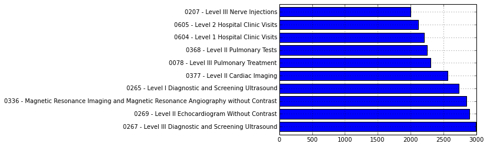

```python
APC_counts[:10].plot(kind='barh')
```

```python
#getData['HCP_Add_State'].value_counts()
State_counts = getData['HCP_Add_State'].value_counts()
State_counts[:10]
```

```
TX    3239
CA    2983
FL    2279
PA    2264
NY    2133
IL    2087
OH    2064
MI    1424
NC    1409
GA    1393
dtype: int64
```

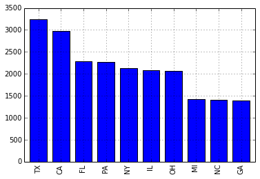

```python
State_counts[:10].plot(kind='bar')
```

### Describe Data

#### Explore data statistics

Once I have confirmed that the data is coming in properly and observed its general structure (string, floats, integrer field), a good second step is to collect some descriptive satistics ont he dataset as a whole.

Grouping the desriptive statistics by a field you are particularly interested helps form a general impression about the way that fields trends in the dataset.

In this case the [APC or Ambulatory Payment Classifications](http://en.wikipedia.org/wiki/Ambulatory_Payment_Classification) field is a good 'groupby' field. Note: The APC claims are related to a Hospitals and reffering hospitals. Phycisians are remberssed through a different system.

```python
APC_describe = getData.groupby("APC").describe()
APC_describe[:10]
```

```
                                                        HCP_Id  \
APC
0012 - Level I Debridement & Destruction  count     290.000000
                                          mean   271517.668966
                                          std    149733.565114
                                          min     20024.000000
                                          25%    140158.750000
                                          50%    260067.000000
                                          75%    390096.250000
                                          max    670034.000000
0013 - Level II Debridement & Destruction count    1479.000000
                                          mean   269293.345504

                                                 HCP_Add_Zip_Code  \
APC
0012 - Level I Debridement & Destruction  count        290.000000
                                          mean       50829.382759
                                          std        30624.874347
                                          min         1069.000000
                                          25%        27116.500000
                                          50%        55087.500000
                                          75%        75584.500000
                                          max        99669.000000
0013 - Level II Debridement & Destruction count       1479.000000
                                          mean       48892.743746

                                                    OPT_Srvc  \
APC
0012 - Level I Debridement & Destruction  count    290.00000
                                          mean     946.30000
                                          std     2256.49538
                                          min       11.00000
                                          25%       28.00000
                                          50%      132.50000
                                          75%      828.00000
                                          max    24527.00000
0013 - Level II Debridement & Destruction count   1479.00000
                                          mean     292.16430

                                                 Avg_Est_Submitted_Charges  \
```

[output cut: 11 more lines]

```

                                                 Avg_Tot_Payments
APC
0012 - Level I Debridement & Destruction  count        290.000000
                                          mean          17.767613
                                          std            4.541913
                                          min            7.305000
                                          25%           14.644603
                                          50%           16.072068
                                          75%           19.526026
                                          max           36.623853
0013 - Level II Debridement & Destruction count       1479.000000
                                          mean          56.142408

[10 rows x 5 columns]
```

#### Visual Exploration of Data

A quick visualization of the loaded data can also provide leads to possible areas of deeper exploration. As in this case, we are looking at claim outliers, we should pay special attention to data that are detached from the primary clustering.

[output not shown]

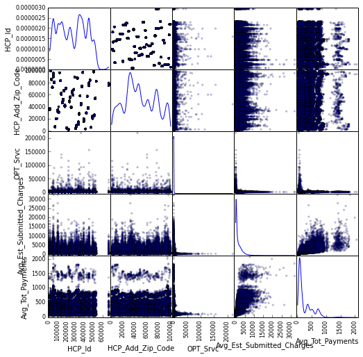

```python
#visually explore the datafrom pandas.tools.plotting import scatter_matrix

pd.scatter_matrix(getData, alpha=0.2, figsize=(8, 8), diagonal='kde')
```

As is clear from the graphs that infact there is a seperation in the claims. Most of the claim payments are clustered tightly together while a smaller set breaks away towards the higher end. The pattern in the data for HCP_Id and Avg_Tot_Payment for example, has the approximatly the same trend as the one for HCP_Add_Zip_Code. This may imply that trend projected by the grpah is independent of geography.

Looking at the scatter plots, claims that had and an Avg_Est_Submitted_Charges above $200,00 for which Avg_Tot_Payments were above$ 1500 are another are of analysis.

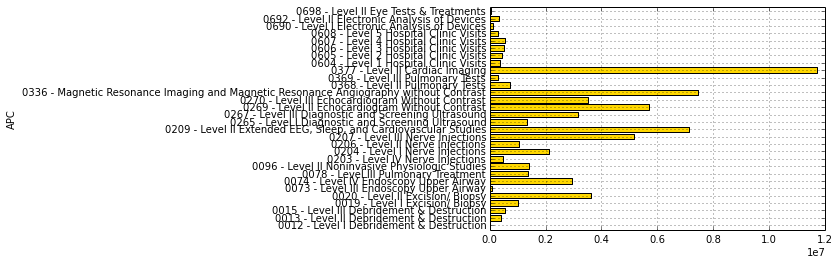

```python
getData.groupby('APC').Avg_Est_Submitted_Charges.sum().plot(kind='barh', color='gold')
```

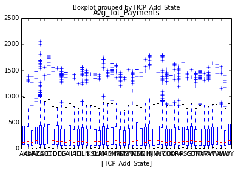

```python
bp = getData.boxplot(column='Avg_Tot_Payments', by='HCP_Add_State', grid=False)
for i in [1,2,3]:
    y = getData.Avg_Tot_Payments[getData.HCP_Add_State==i].dropna()
    # Add some random "jitter" to the x-axis
    x = np.random.normal(i, 0.04, size=len(y))
    pl.plot(x, y, 'r.', alpha=0.2)
```

# Next Predictive Modeling, Communicating Results ...